# Collaborating on Reproducible Code Using R and GitHub

13/01/2021

## Schedule

1. **Working in different contexts:** RStudio Projects
2. **Dynamic document generation:** RMarkdown
3. **Version control:** Git + GitHub
4. **Environment management**: renv
5. **Containerization**: Docker
6. **Start collaborating**

## 0. Kudos

- Peikert, A., & Brandmaier, A. M. (2020). A Reproducible Data Analysis Workflow with R Markdown, Git, Make, and Docker. https://doi.org/10.31234/osf.io/8xzqy

[figure not shown]

## 1. Working in different contexts: RStudio Projects - What & Why?

[figure not shown]

- **What it does**:
  - Allows to work in multiple different contexts (projects), e.g. one for each experiment
  - Each project is own working directory, workspace, history, and source documents
  - Each project is associated with a folder on your computer (= working directory)
- **Why it helps**:
  - Have a separate, shareable working environment for each experiment
  - Keep all the files associated with a project together — data, scripts, results, figures
  - Work on multiple projects at once, each associated with its packages (and package versions), loaded data, etc.
  - Use only relative paths
  - Necessary basis for version control

## 1. Working in different contexts: RStudio Projects – How?

- In RStudio: File > New Project > …
- (Example using the sleepstudy data set from lme4)

## 2. Dynamic document generation: RMarkdown - What & Why?

[figure not shown]

- **What it does:**
  - Creates dynamic documents with embedded chunks of code (R, python, Julia, stan, …), computed results , written text etc. (= LaTex)
  - Markdown-files can be exported to documents (docx, rtf), presentations, pdfs, or websites (html) e.g using the `knitr` (Xie, 2015, 2020) and `tinytex` (Xie, 2015, 2020; for pdfs)
  - R code is dynamically rendered, and can be given in separate chunks (’’‘{r}’’‘) or inline (’ r … ’)
- **Why it helps:**
  - Simple language (\(\neq\) LaTex)
  - Integrates directly with statistical software (R Studio)
  - Saves code and output in one file
  - Reduces copy&paste errors: reported results consistent with actual results

## 3. Version control: Git + GitHub - What & Why?

[figure not shown]

## 4. Environment management: renv

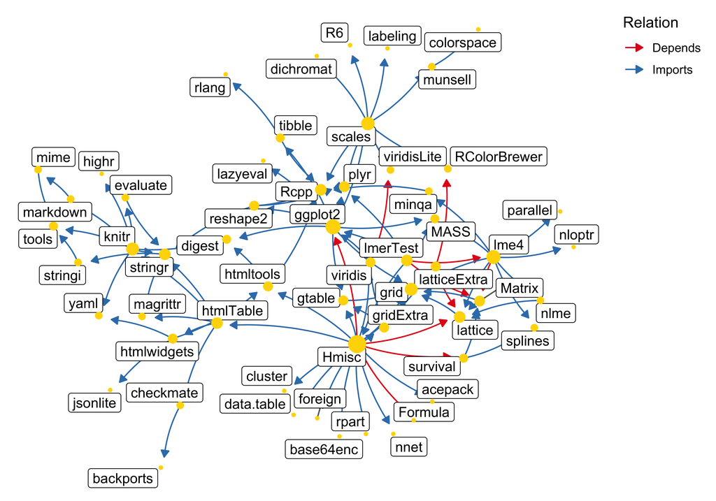

## 4. renv – What & Why?

- What it does:
  - Creates a project-specific library of packages in the project folder
  - Overwrites `install.packages()` to install packages there
  - Keeps track of package versions in the `renv.lock` file
- Why it helps:
  - Keeps package versions untouched by other projects
  - Allows you to revert to the previous state when an update has broken your analysis
  - Makes it easier to share package versions with your collaborators (e.g., via GitHub)

## 4. renv – How?

1. Install the renv package: `install.packages(renv)`
2. Initialize your project library: `renv::init()`
3. Install and update your packages as usual: `install.packages("pkgname")`
4. Save the current state of the project library: `renv::snapshot()`
5. Revert to a previous state if an update caused problems: `renv::restore()`

You can skip step #2 if you select “Use renv with this project” during project creation.

## 5. Containerization: Docker

[figure not shown]